# BUSINESS PROJECT

## Business Statistics Project

### W132/G/12605/24

### Dec/10/12

## Problem Statement

The company has introduced a new landing page and wants to evaluate whether it performs better than the old page. Specifically, the goal is to determine if the new page increases user engagement (time spent on the page) and improves conversion rates, while also checking if language preference influences these outcomes.

## Objectives

1. Explore and clean the dataset using pandas.
2. Visualize distributions and group comparisons with matplotlib and seaborn.
3. Perform hypothesis tests:
   - **t-test**: Compare mean time spent between old and new pages.
   - **Proportion test**: Compare conversion rates between old and new pages.
   - **Chi-square test**: Assess independence between conversion and language preference.
   - **ANOVA**: Test differences in time spent across languages (new page only).
4. Interpret results and provide business insights.

```python
# Step 1: Import Libraries

!pip install numpy pandas matplotlib seaborn scipy statsmodels --user
import numpy as np
import pandas as pd
import matplotlib.pyplot as plt
import seaborn as sns
from scipy import stats
from statsmodels.stats.proportion import proportions_ztest


# Step 2: Load Data
df = pd.read_csv("C://Users//Administrator//Documents//abtest.csv")


# Step 3: Data Overview
print(df.head())
print(df.tail())
print("Shape:", df.shape)
print(df.describe())
print("Missing values:\n", df.isnull().sum())
print("Duplicate rows:", df.duplicated().sum())
```

```
   user_id      group landing_page  time_spent_on_the_page converted  \
0   546592    control          old                    3.48        no
1   546468  treatment          new                    7.13       yes
2   546462  treatment          new                    4.40        no
3   546567    control          old                    3.02        no
4   546459  treatment          new                    4.75       yes

  language_preferred
0            Spanish
1            English
2            Spanish
3             French
4            Spanish
    user_id      group landing_page  time_spent_on_the_page converted  \
95   546446  treatment          new                    5.15        no
96   546544    control          old                    6.52       yes
97   546472  treatment          new                    7.07       yes
98   546481  treatment          new                    6.20       yes
99   546483  treatment          new                    5.86       yes

   language_preferred
95            Spanish
96            English
97            Spanish
98            Spanish
99            English
Shape: (100, 6)
             user_id  time_spent_on_the_page
count     100.000000              100.000000
mean   546517.000000                5.377800
std        52.295779                2.378166
min    546443.000000                0.190000
25%    546467.750000                3.880000
50%    546492.500000                5.415000
75%    546567.250000                7.022500
max    546592.000000               10.710000
Missing values:
 user_id                   0
group                     0
landing_page              0
time_spent_on_the_page    0
converted                 0
language_preferred        0
dtype: int64
Duplicate rows: 0
```

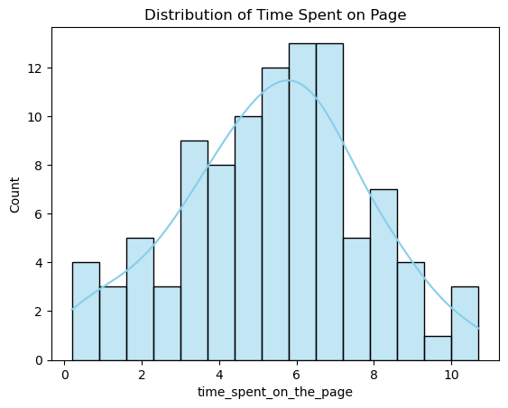

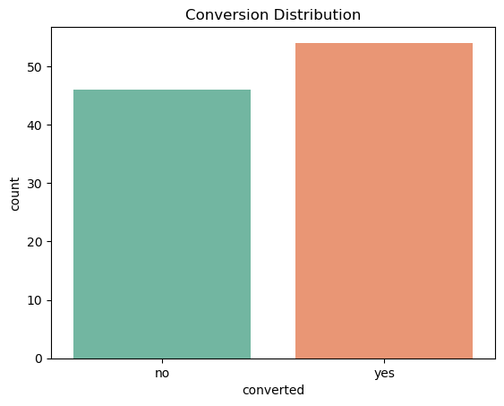

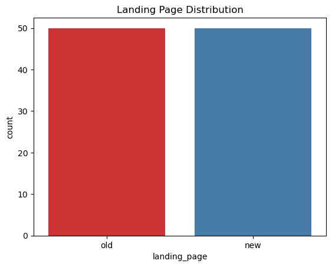

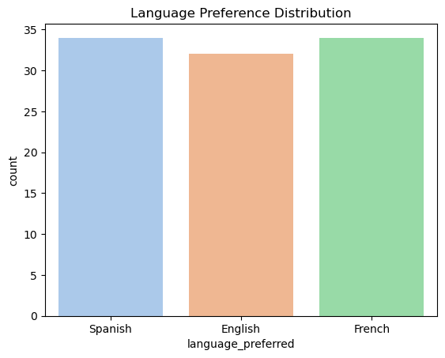

```
count    100.000000
mean       5.377800
std        2.378166
min        0.190000
25%        3.880000
50%        5.415000
75%        7.022500
max       10.710000
Name: time_spent_on_the_page, dtype: float64
```

```python
# Step 4: Univariate Analysis

sns.histplot(df['time_spent_on_the_page'], bins=15, kde=True, color='skyblue')
plt.title("Distribution of Time Spent on Page")
plt.show()

sns.countplot(x='converted', hue='converted', data=df, palette='Set2', legend=False)
plt.title("Conversion Distribution")
plt.show()

sns.countplot(x='landing_page', hue='landing_page', data=df, palette='Set1', legend=False)
plt.title("Landing Page Distribution")
plt.show()

sns.countplot(x='language_preferred', hue='language_preferred', data=df, palette='pastel', legend=False)
plt.title("Language Preference Distribution")
plt.show()

print(df['time_spent_on_the_page'].describe())
```

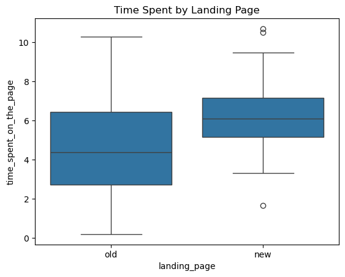

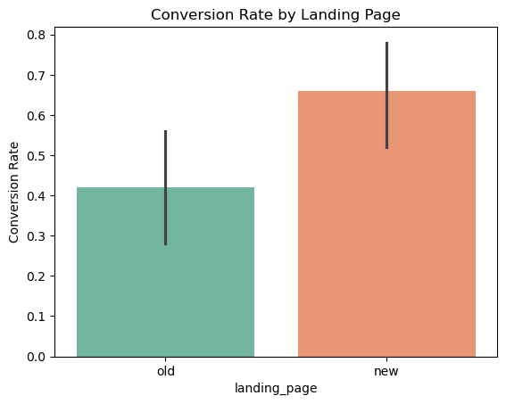

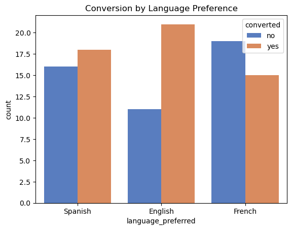

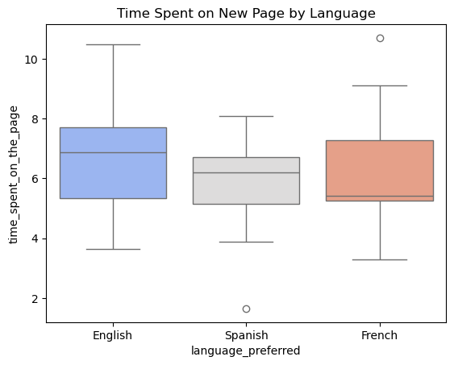

```python
# Step 5: Bivariate Analysis

import pandas as pd
import seaborn as sns
import matplotlib.pyplot as plt
df = pd.read_csv("C://Users//Administrator//Documents//abtest.csv")

sns.boxplot(x='landing_page', y='time_spent_on_the_page',  data=df)
plt.title("Time Spent by Landing Page")
plt.show()

sns.barplot(x='landing_page', y=df['converted'].map({'yes':1,'no':0}),  data=df, palette='Set2')
plt.title("Conversion Rate by Landing Page")
plt.ylabel("Conversion Rate")
plt.show()

sns.countplot(x='language_preferred', hue='converted', data=df, palette='muted')
plt.title("Conversion by Language Preference")
plt.show()

sns.boxplot(x='language_preferred', y='time_spent_on_the_page',
            data=df[df['landing_page']=="new"], palette='coolwarm')
plt.title("Time Spent on New Page by Language")
plt.show()
```

```python
# Step 6: Hypothesis Testing

# 1. Time spent on new vs old page
old = df[df['landing_page']=="old"]["time_spent_on_the_page"]
new = df[df['landing_page']=="new"]["time_spent_on_the_page"]

t_stat, p_val = stats.ttest_ind(new, old, alternative="greater")
print("T-test: T-statistic =", t_stat, "P-value =", p_val)
```

```
T-test: T-statistic = 3.7867702694199856 P-value = 0.0001316123528095005
```

### Observation: Time Spent on New vs Old Page

- The p-value is < than 0.05 ,which shows that the users spend significantly more time on the new landing page.

```python
# 2. Conversion rate comparison
convert_counts = np.array([
    (df[(df['landing_page']=="new") & (df['converted']=="yes")].shape[0]),
    (df[(df['landing_page']=="old") & (df['converted']=="yes")].shape[0])
])
nobs = np.array([
    df[df['landing_page']=="new"].shape[0],
    df[df['landing_page']=="old"].shape[0]
])

z_stat, p_val = proportions_ztest(convert_counts, nobs, alternative="larger")
print("Z-test: Z-statistic =", z_stat, "P-value =", p_val)
```

```
Z-test: Z-statistic = 2.4077170617153842 P-value = 0.008026308204056278
```

### Observation: Conversion Rate Comparison

- The p-value is < than 0.05, which suggests that conversion rate is significantly higher on the new page.

```python
# 3. Conversion vs language independence
contingency = pd.crosstab(df['converted'], df['language_preferred'])
chi2, p_val, dof, expected = stats.chi2_contingency(contingency)
print("Chi-square: Chi2 =", chi2, "P-value =", p_val)
```

```
Chi-square: Chi2 = 3.0930306905370837 P-value = 0.21298887487543447
```

### Observation: Conversion vs Language Independence

- The p-value is > than 0.05, showing that conversion outcomes are not affected by language preference.

```python
# 4. Time spent across languages (new page only)
new_page = df[df['landing_page']=="new"]
groups = [group["time_spent_on_the_page"].values for name, group in new_page.groupby("language_preferred")]
f_stat, p_val = stats.f_oneway(*groups)
print("ANOVA: F-statistic =", f_stat, "P-value =", p_val)
```

```
ANOVA: F-statistic = 0.8543992770006822 P-value = 0.43204138694325955
```

### Observation: Time Spent Across Languages (New Page)

- The p-value is > than 0.05, indicating that time spent is consistent across languages.

## Conclusion

The new landing page is clearly better:

- People stay longer.
- More of them convert.
- Performance is consistent across languages.

## Business Recommendation

- I suggest we release the new landing page to all users: Since it clearly performs better and people spend more time on it.
- Their is no need for separate designs by language : Since language does not affect conversion or time spent.